# Bellabeat Case Study

Ruiying Yang

### 1. All about the company - Bellabeat

Bellabeat is a high-tech manufacturer of health-focused products for women and it is a successful small company, but they have the potential to become a larger player in the global smart device market. Urška Sršen, cofounder and Chief Creative Officer of Bellabeat, believes that analyzing smart device fitness data could help unlock new growth opportunities for the company.

### 2. Ask

#### 2.1 Identify the business task

1. What are some trends in smart device usage?
2. How could these trends apply to Bellabeat customers?
3. How could these trends help influence Bellabeat marketing strategy?

#### 2.2 Key stakeholders

1. Urška Sršen: Bellabeat’s cofounder and Chief Creative Officer.
2. Sando Mur: Mathematician and Bellabeat’s cofounder.
3. Bellabeat marketing analytics team.

### 3. Prepare

#### 3.2 The structure and some basic statistic info of the data

##### 3.2.1 Install the necessary packages and import the data.

```r
#install.packages("sqldf")
library(pacman)
p_load(moments,
       ggplot2,
       cowplot,
       RColorBrewer,
       stargazer,
       tidyverse,
       sqldf,
       lubridate,
       dplyr)

getwd()
```

```
## [1] "/Users/yangruiying/Desktop/Data Analyse/Bellabeat_Case_Study"
```

```r
Activity <- read.csv("/Users/yangruiying/Desktop/Data\ Analyse/Bellabeat_Case_Study/Fitabase\ Data/dailyActivity_merged.csv", stringsAsFactors = T, header = T, sep = ",")

Calories <- read.csv("/Users/yangruiying/Desktop/Data\ Analyse/Bellabeat_Case_Study/Fitabase\ Data/dailyCalories_merged.csv", stringsAsFactors = T, header = T, sep = "," )

Steps <- read.csv("/Users/yangruiying/Desktop/Data\ Analyse/Bellabeat_Case_Study/Fitabase\ Data/dailySteps_merged.csv", stringsAsFactors = T, header = T, sep = "," )

Weight <- read.csv("/Users/yangruiying/Desktop/Data\ Analyse/Bellabeat_Case_Study/Fitabase\ Data/weightLogInfo_merged.csv", stringsAsFactors = T, header = T, sep = "," )

Intensity <- read.csv("/Users/yangruiying/Desktop/Data\ Analyse/Bellabeat_Case_Study/Fitabase\ Data/dailyIntensities_merged.csv", stringsAsFactors = T, header = T, sep = "," )

Sleep <- read.csv("/Users/yangruiying/Desktop/Data\ Analyse/Bellabeat_Case_Study/Fitabase\ Data/sleepDay_merged.csv", stringsAsFactors = T, header = T, sep = "," )

HourlyIntensity <- read.csv("/Users/yangruiying/Desktop/Data\ Analyse/Bellabeat_Case_Study/Fitabase\ Data/hourlyIntensities_merged.csv", stringsAsFactors = T, header = T, sep = "," )
```

##### 3.2.2 How the data is organized.

```r
str(Activity)
```

```
## 'data.frame':    940 obs. of  15 variables:
##  $ Id                      : num  1.5e+09 1.5e+09 1.5e+09 1.5e+09 1.5e+09 ...
##  $ ActivityDate            : Factor w/ 31 levels "4/12/2016","4/13/2016",..: 1 2 3 4 5 6 7 8 9 10 ...
##  $ TotalSteps              : int  13162 10735 10460 9762 12669 9705 13019 15506 10544 9819 ...
##  $ TotalDistance           : num  8.5 6.97 6.74 6.28 8.16 ...
##  $ TrackerDistance         : num  8.5 6.97 6.74 6.28 8.16 ...
##  $ LoggedActivitiesDistance: num  0 0 0 0 0 0 0 0 0 0 ...
##  $ VeryActiveDistance      : num  1.88 1.57 2.44 2.14 2.71 ...
##  $ ModeratelyActiveDistance: num  0.55 0.69 0.4 1.26 0.41 ...
##  $ LightActiveDistance     : num  6.06 4.71 3.91 2.83 5.04 ...
##  $ SedentaryActiveDistance : num  0 0 0 0 0 0 0 0 0 0 ...
##  $ VeryActiveMinutes       : int  25 21 30 29 36 38 42 50 28 19 ...
##  $ FairlyActiveMinutes     : int  13 19 11 34 10 20 16 31 12 8 ...
##  $ LightlyActiveMinutes    : int  328 217 181 209 221 164 233 264 205 211 ...
##  $ SedentaryMinutes        : int  728 776 1218 726 773 539 1149 775 818 838 ...
##  $ Calories                : int  1985 1797 1776 1745 1863 1728 1921 2035 1786 1775 ...
```

```r
head(Activity)
```

```
##           Id ActivityDate TotalSteps TotalDistance TrackerDistance
## 1 1503960366    4/12/2016      13162          8.50            8.50
## 2 1503960366    4/13/2016      10735          6.97            6.97
## 3 1503960366    4/14/2016      10460          6.74            6.74
## 4 1503960366    4/15/2016       9762          6.28            6.28
## 5 1503960366    4/16/2016      12669          8.16            8.16
## 6 1503960366    4/17/2016       9705          6.48            6.48
##   LoggedActivitiesDistance VeryActiveDistance ModeratelyActiveDistance
## 1                        0               1.88                     0.55
## 2                        0               1.57                     0.69
## 3                        0               2.44                     0.40
## 4                        0               2.14                     1.26
## 5                        0               2.71                     0.41
## 6                        0               3.19                     0.78
##   LightActiveDistance SedentaryActiveDistance VeryActiveMinutes
## 1                6.06                       0                25
## 2                4.71                       0                21
## 3                3.91                       0                30
## 4                2.83                       0                29
## 5                5.04                       0                36
## 6                2.51                       0                38
##   FairlyActiveMinutes LightlyActiveMinutes SedentaryMinutes Calories
## 1                  13                  328              728     1985
## 2                  19                  217              776     1797
## 3                  11                  181             1218     1776
## 4                  34                  209              726     1745
## 5                  10                  221              773     1863
## 6                  20                  164              539     1728
```

```r
str(Calories)
```

```
## 'data.frame':    940 obs. of  3 variables:
##  $ Id         : num  1.5e+09 1.5e+09 1.5e+09 1.5e+09 1.5e+09 ...
##  $ ActivityDay: Factor w/ 31 levels "4/12/2016","4/13/2016",..: 1 2 3 4 5 6 7 8 9 10 ...
##  $ Calories   : int  1985 1797 1776 1745 1863 1728 1921 2035 1786 1775 ...
```

```r
head(Calories)
```

```
##           Id ActivityDay Calories
## 1 1503960366   4/12/2016     1985
## 2 1503960366   4/13/2016     1797
## 3 1503960366   4/14/2016     1776
## 4 1503960366   4/15/2016     1745
## 5 1503960366   4/16/2016     1863
## 6 1503960366   4/17/2016     1728
```

```r
str(Steps)
```

```
## 'data.frame':    940 obs. of  3 variables:
##  $ Id         : num  1.5e+09 1.5e+09 1.5e+09 1.5e+09 1.5e+09 ...
##  $ ActivityDay: Factor w/ 31 levels "4/12/2016","4/13/2016",..: 1 2 3 4 5 6 7 8 9 10 ...
##  $ StepTotal  : int  13162 10735 10460 9762 12669 9705 13019 15506 10544 9819 ...
```

```r
head(Steps)
```

```
##           Id ActivityDay StepTotal
## 1 1503960366   4/12/2016     13162
## 2 1503960366   4/13/2016     10735
## 3 1503960366   4/14/2016     10460
## 4 1503960366   4/15/2016      9762
## 5 1503960366   4/16/2016     12669
## 6 1503960366   4/17/2016      9705
```

```r
str(Weight)
```

```
## 'data.frame':    67 obs. of  8 variables:
##  $ Id            : num  1.50e+09 1.50e+09 1.93e+09 2.87e+09 2.87e+09 ...
##  $ Date          : Factor w/ 56 levels "4/12/2016 11:59:59 PM",..: 44 45 3 19 42 11 47 13 26 37 ...
##  $ WeightKg      : num  52.6 52.6 133.5 56.7 57.3 ...
##  $ WeightPounds  : num  116 116 294 125 126 ...
##  $ Fat           : int  22 NA NA NA NA 25 NA NA NA NA ...
##  $ BMI           : num  22.6 22.6 47.5 21.5 21.7 ...
##  $ IsManualReport: Factor w/ 2 levels "False","True": 2 2 1 2 2 2 2 2 2 2 ...
##  $ LogId         : num  1.46e+12 1.46e+12 1.46e+12 1.46e+12 1.46e+12 ...
```

```r
head(Weight)
```

```
##           Id                  Date WeightKg WeightPounds Fat   BMI
## 1 1503960366  5/2/2016 11:59:59 PM     52.6     115.9631  22 22.65
## 2 1503960366  5/3/2016 11:59:59 PM     52.6     115.9631  NA 22.65
## 3 1927972279  4/13/2016 1:08:52 AM    133.5     294.3171  NA 47.54
## 4 2873212765 4/21/2016 11:59:59 PM     56.7     125.0021  NA 21.45
## 5 2873212765 5/12/2016 11:59:59 PM     57.3     126.3249  NA 21.69
## 6 4319703577 4/17/2016 11:59:59 PM     72.4     159.6147  25 27.45
##   IsManualReport        LogId
## 1           True 1.462234e+12
## 2           True 1.462320e+12
## 3          False 1.460510e+12
## 4           True 1.461283e+12
## 5           True 1.463098e+12
## 6           True 1.460938e+12
```

```r
str(Intensity)
```

```
## 'data.frame':    940 obs. of  10 variables:
##  $ Id                      : num  1.5e+09 1.5e+09 1.5e+09 1.5e+09 1.5e+09 ...
##  $ ActivityDay             : Factor w/ 31 levels "4/12/2016","4/13/2016",..: 1 2 3 4 5 6 7 8 9 10 ...
##  $ SedentaryMinutes        : int  728 776 1218 726 773 539 1149 775 818 838 ...
##  $ LightlyActiveMinutes    : int  328 217 181 209 221 164 233 264 205 211 ...
##  $ FairlyActiveMinutes     : int  13 19 11 34 10 20 16 31 12 8 ...
##  $ VeryActiveMinutes       : int  25 21 30 29 36 38 42 50 28 19 ...
##  $ SedentaryActiveDistance : num  0 0 0 0 0 0 0 0 0 0 ...
##  $ LightActiveDistance     : num  6.06 4.71 3.91 2.83 5.04 ...
##  $ ModeratelyActiveDistance: num  0.55 0.69 0.4 1.26 0.41 ...
##  $ VeryActiveDistance      : num  1.88 1.57 2.44 2.14 2.71 ...
```

```r
head(Intensity)
```

```
##           Id ActivityDay SedentaryMinutes LightlyActiveMinutes
## 1 1503960366   4/12/2016              728                  328
## 2 1503960366   4/13/2016              776                  217
## 3 1503960366   4/14/2016             1218                  181
## 4 1503960366   4/15/2016              726                  209
## 5 1503960366   4/16/2016              773                  221
## 6 1503960366   4/17/2016              539                  164
##   FairlyActiveMinutes VeryActiveMinutes SedentaryActiveDistance
## 1                  13                25                       0
## 2                  19                21                       0
## 3                  11                30                       0
## 4                  34                29                       0
## 5                  10                36                       0
## 6                  20                38                       0
##   LightActiveDistance ModeratelyActiveDistance VeryActiveDistance
## 1                6.06                     0.55               1.88
## 2                4.71                     0.69               1.57
## 3                3.91                     0.40               2.44
## 4                2.83                     1.26               2.14
## 5                5.04                     0.41               2.71
## 6                2.51                     0.78               3.19
```

```r
str(Sleep)
```

```
## 'data.frame':    413 obs. of  5 variables:
##  $ Id                : num  1.5e+09 1.5e+09 1.5e+09 1.5e+09 1.5e+09 ...
##  $ SleepDay          : Factor w/ 31 levels "4/12/2016 12:00:00 AM",..: 1 2 4 5 6 8 9 10 12 13 ...
##  $ TotalSleepRecords : int  1 2 1 2 1 1 1 1 1 1 ...
##  $ TotalMinutesAsleep: int  327 384 412 340 700 304 360 325 361 430 ...
##  $ TotalTimeInBed    : int  346 407 442 367 712 320 377 364 384 449 ...
```

```r
head(Sleep)
```

```
##           Id              SleepDay TotalSleepRecords TotalMinutesAsleep
## 1 1503960366 4/12/2016 12:00:00 AM                 1                327
## 2 1503960366 4/13/2016 12:00:00 AM                 2                384
## 3 1503960366 4/15/2016 12:00:00 AM                 1                412
## 4 1503960366 4/16/2016 12:00:00 AM                 2                340
## 5 1503960366 4/17/2016 12:00:00 AM                 1                700
## 6 1503960366 4/19/2016 12:00:00 AM                 1                304
##   TotalTimeInBed
## 1            346
## 2            407
## 3            442
## 4            367
## 5            712
## 6            320
```

```r
str(HourlyIntensity)
```

```
## 'data.frame':    22099 obs. of  4 variables:
##  $ Id              : num  1.5e+09 1.5e+09 1.5e+09 1.5e+09 1.5e+09 ...
##  $ ActivityHour    : Factor w/ 736 levels "4/12/2016 1:00:00 AM",..: 7 1 9 11 13 15 17 19 21 23 ...
##  $ TotalIntensity  : int  20 8 7 0 0 0 0 0 13 30 ...
##  $ AverageIntensity: num  0.333 0.133 0.117 0 0 ...
```

```r
head(HourlyIntensity)
```

```
##           Id          ActivityHour TotalIntensity AverageIntensity
## 1 1503960366 4/12/2016 12:00:00 AM             20         0.333333
## 2 1503960366  4/12/2016 1:00:00 AM              8         0.133333
## 3 1503960366  4/12/2016 2:00:00 AM              7         0.116667
## 4 1503960366  4/12/2016 3:00:00 AM              0         0.000000
## 5 1503960366  4/12/2016 4:00:00 AM              0         0.000000
## 6 1503960366  4/12/2016 5:00:00 AM              0         0.000000
```

- Activity table: There are 940 records and 15 variables, most of the data are numerical and integer. Many people recorded their activity for many days. Most of the variables are grouped according to the amount and intensity of the activities.
- Calories table: There are 940 obs. of 3 variables. The data is also grouped by different customer Ids. But we can notice that, the data in the table calories overlapped with the data in the table Activity. So the data in this table can be just replaced with the analysis of the data in the table Activity.
- Steps table: There are also 940 obs. of 3 variables. The case for this table is the same as the table calories. Because all the variables are included in the Activity data, this table will not be included in our analysis.
- Weight table: There are 67 obs. of 8 variables. Since there are some different rows in this table and there is also Id column, so it can be merged with the data in the table Acitivity.
- Intensity table: There are 940 obs. of 10 variables. All the data are included in the table Acitivity, so we will exclude this table from our analysis.
- Sleep table: There are 413 obs. of 5 variables. We can see that many users record their sleep for many different days, which means maybe what the most important function of the fitness app is to record the sleep. We can still merge this data with the data in the table Activity.
- HourlyIntensity table: There are 22099 obs. of 4 variables. There are so many objects in this table because the intensity is recorded for many times in a day. Since the data in the table Intensity is overlapped with the data in Activity table, we could use this table to examine the time period of doing sport.

We can also notice that the data is store in the long format. After the first peek into the data, we decided that we will analyze the following tables: • Activity • Weight • Sleep • HourlyIntensity

##### 3.2.3 Statistical information of the data

```r
summary(Activity)
```

```
##        Id               ActivityDate   TotalSteps    TotalDistance
##  Min.   :1.504e+09   4/12/2016: 33   Min.   :    0   Min.   : 0.000
##  1st Qu.:2.320e+09   4/13/2016: 33   1st Qu.: 3790   1st Qu.: 2.620
##  Median :4.445e+09   4/14/2016: 33   Median : 7406   Median : 5.245
##  Mean   :4.855e+09   4/15/2016: 33   Mean   : 7638   Mean   : 5.490
##  3rd Qu.:6.962e+09   4/16/2016: 32   3rd Qu.:10727   3rd Qu.: 7.713
##  Max.   :8.878e+09   4/17/2016: 32   Max.   :36019   Max.   :28.030
##                      (Other)  :744
##  TrackerDistance  LoggedActivitiesDistance VeryActiveDistance
##  Min.   : 0.000   Min.   :0.0000           Min.   : 0.000
##  1st Qu.: 2.620   1st Qu.:0.0000           1st Qu.: 0.000
##  Median : 5.245   Median :0.0000           Median : 0.210
##  Mean   : 5.475   Mean   :0.1082           Mean   : 1.503
##  3rd Qu.: 7.710   3rd Qu.:0.0000           3rd Qu.: 2.053
##  Max.   :28.030   Max.   :4.9421           Max.   :21.920
##
##  ModeratelyActiveDistance LightActiveDistance SedentaryActiveDistance
##  Min.   :0.0000           Min.   : 0.000      Min.   :0.000000
##  1st Qu.:0.0000           1st Qu.: 1.945      1st Qu.:0.000000
##  Median :0.2400           Median : 3.365      Median :0.000000
##  Mean   :0.5675           Mean   : 3.341      Mean   :0.001606
##  3rd Qu.:0.8000           3rd Qu.: 4.782      3rd Qu.:0.000000
##  Max.   :6.4800           Max.   :10.710      Max.   :0.110000
##
##  VeryActiveMinutes FairlyActiveMinutes LightlyActiveMinutes SedentaryMinutes
##  Min.   :  0.00    Min.   :  0.00      Min.   :  0.0        Min.   :   0.0
##  1st Qu.:  0.00    1st Qu.:  0.00      1st Qu.:127.0        1st Qu.: 729.8
##  Median :  4.00    Median :  6.00      Median :199.0        Median :1057.5
##  Mean   : 21.16    Mean   : 13.56      Mean   :192.8        Mean   : 991.2
##  3rd Qu.: 32.00    3rd Qu.: 19.00      3rd Qu.:264.0        3rd Qu.:1229.5
##  Max.   :210.00    Max.   :143.00      Max.   :518.0        Max.   :1440.0
##
##     Calories
##  Min.   :   0
##  1st Qu.:1828
##  Median :2134
##  Mean   :2304
##  3rd Qu.:2793
##  Max.   :4900
##
```

```r
summary(Weight)
```

```
##        Id                               Date       WeightKg
##  Min.   :1.504e+09   5/2/2016 11:59:59 PM : 3   Min.   : 52.60
##  1st Qu.:6.962e+09   4/17/2016 11:59:59 PM: 2   1st Qu.: 61.40
##  Median :6.962e+09   4/18/2016 11:59:59 PM: 2   Median : 62.50
##  Mean   :7.009e+09   4/21/2016 11:59:59 PM: 2   Mean   : 72.04
##  3rd Qu.:8.878e+09   4/25/2016 11:59:59 PM: 2   3rd Qu.: 85.05
##  Max.   :8.878e+09   5/1/2016 11:59:59 PM : 2   Max.   :133.50
##                      (Other)              :54
##   WeightPounds        Fat             BMI        IsManualReport
##  Min.   :116.0   Min.   :22.00   Min.   :21.45   False:26
##  1st Qu.:135.4   1st Qu.:22.75   1st Qu.:23.96   True :41
##  Median :137.8   Median :23.50   Median :24.39
##  Mean   :158.8   Mean   :23.50   Mean   :25.19
##  3rd Qu.:187.5   3rd Qu.:24.25   3rd Qu.:25.56
##  Max.   :294.3   Max.   :25.00   Max.   :47.54
##                  NA's   :65
##      LogId
##  Min.   :1.460e+12
##  1st Qu.:1.461e+12
##  Median :1.462e+12
##  Mean   :1.462e+12
##  3rd Qu.:1.462e+12
##  Max.   :1.463e+12
##
```

```r
summary(Sleep)
```

```
##        Id                             SleepDay   TotalSleepRecords
##  Min.   :1.504e+09   4/15/2016 12:00:00 AM: 17   Min.   :1.000
##  1st Qu.:3.977e+09   4/28/2016 12:00:00 AM: 16   1st Qu.:1.000
##  Median :4.703e+09   5/1/2016 12:00:00 AM : 16   Median :1.000
##  Mean   :5.001e+09   4/20/2016 12:00:00 AM: 15   Mean   :1.119
##  3rd Qu.:6.962e+09   4/21/2016 12:00:00 AM: 15   3rd Qu.:1.000
##  Max.   :8.792e+09   4/23/2016 12:00:00 AM: 15   Max.   :3.000
##                      (Other)              :319
##  TotalMinutesAsleep TotalTimeInBed
##  Min.   : 58.0      Min.   : 61.0
##  1st Qu.:361.0      1st Qu.:403.0
##  Median :433.0      Median :463.0
##  Mean   :419.5      Mean   :458.6
##  3rd Qu.:490.0      3rd Qu.:526.0
##  Max.   :796.0      Max.   :961.0
##
```

```r
summary(HourlyIntensity)
```

```
##        Id                           ActivityHour   TotalIntensity
##  Min.   :1.504e+09   4/12/2016 1:00:00 AM :   33   Min.   :  0.00
##  1st Qu.:2.320e+09   4/12/2016 1:00:00 PM :   33   1st Qu.:  0.00
##  Median :4.445e+09   4/12/2016 10:00:00 AM:   33   Median :  3.00
##  Mean   :4.848e+09   4/12/2016 10:00:00 PM:   33   Mean   : 12.04
##  3rd Qu.:6.962e+09   4/12/2016 11:00:00 AM:   33   3rd Qu.: 16.00
##  Max.   :8.878e+09   4/12/2016 11:00:00 PM:   33   Max.   :180.00
##                      (Other)              :21901
##  AverageIntensity
##  Min.   :0.0000
##  1st Qu.:0.0000
##  Median :0.0500
##  Mean   :0.2006
##  3rd Qu.:0.2667
##  Max.   :3.0000
##
```

```r
n_distinct(Activity$Id)
```

```
## [1] 33
```

```r
n_distinct(Weight$Id)
```

```
## [1] 8
```

```r
n_distinct(Sleep$Id)
```

```
## [1] 24
```

```r
n_distinct(HourlyIntensity$Id)
```

```
## [1] 33
```

### 4. Process

#### 4.1 Missing values

```r
# Check for explicit and implicit missing values
colSums(is.na(Activity))
```

```
##                       Id             ActivityDate               TotalSteps
##                        0                        0                        0
##            TotalDistance          TrackerDistance LoggedActivitiesDistance
##                        0                        0                        0
##       VeryActiveDistance ModeratelyActiveDistance      LightActiveDistance
##                        0                        0                        0
##  SedentaryActiveDistance        VeryActiveMinutes      FairlyActiveMinutes
##                        0                        0                        0
##     LightlyActiveMinutes         SedentaryMinutes                 Calories
##                        0                        0                        0
```

```r
colSums(Activity == "")
```

```
##                       Id             ActivityDate               TotalSteps
##                        0                        0                        0
##            TotalDistance          TrackerDistance LoggedActivitiesDistance
##                        0                        0                        0
##       VeryActiveDistance ModeratelyActiveDistance      LightActiveDistance
##                        0                        0                        0
##  SedentaryActiveDistance        VeryActiveMinutes      FairlyActiveMinutes
##                        0                        0                        0
##     LightlyActiveMinutes         SedentaryMinutes                 Calories
##                        0                        0                        0
```

```r
colSums(is.na(Weight))
```

```
##             Id           Date       WeightKg   WeightPounds            Fat
##              0              0              0              0             65
##            BMI IsManualReport          LogId
##              0              0              0
```

```r
colSums(Weight == "")
```

```
##             Id           Date       WeightKg   WeightPounds            Fat
##              0              0              0              0             NA
##            BMI IsManualReport          LogId
##              0              0              0
```

```r
colSums(is.na(Sleep))
```

```
##                 Id           SleepDay  TotalSleepRecords TotalMinutesAsleep
##                  0                  0                  0                  0
##     TotalTimeInBed
##                  0
```

```r
colSums(Sleep == "")
```

```
##                 Id           SleepDay  TotalSleepRecords TotalMinutesAsleep
##                  0                  0                  0                  0
##     TotalTimeInBed
##                  0
```

```r
colSums(is.na(HourlyIntensity))
```

```
##               Id     ActivityHour   TotalIntensity AverageIntensity
##                0                0                0                0
```

```r
colSums(HourlyIntensity == "")
```

```
##               Id     ActivityHour   TotalIntensity AverageIntensity
##                0                0                0                0
```

```r
Weight <- Weight[, -5]
str(Weight)
```

```
## 'data.frame':    67 obs. of  7 variables:
##  $ Id            : num  1.50e+09 1.50e+09 1.93e+09 2.87e+09 2.87e+09 ...
##  $ Date          : Factor w/ 56 levels "4/12/2016 11:59:59 PM",..: 44 45 3 19 42 11 47 13 26 37 ...
##  $ WeightKg      : num  52.6 52.6 133.5 56.7 57.3 ...
##  $ WeightPounds  : num  116 116 294 125 126 ...
##  $ BMI           : num  22.6 22.6 47.5 21.5 21.7 ...
##  $ IsManualReport: Factor w/ 2 levels "False","True": 2 2 1 2 2 2 2 2 2 2 ...
##  $ LogId         : num  1.46e+12 1.46e+12 1.46e+12 1.46e+12 1.46e+12 ...
```

#### 4.2 Duplicates

```r
sum(duplicated(Activity))
```

```
## [1] 0
```

```r
sum(duplicated(Weight))
```

```
## [1] 0
```

```r
sum(duplicated(Sleep))
```

```
## [1] 3
```

```r
sum(duplicated(HourlyIntensity))
```

```
## [1] 0
```

```r
Sleep <- Sleep %>%
  distinct()
```

We can see that there are 3 duplicates in the table Sleep. The duplicates are deleted.

#### 4.3 Consistency of date and time columns

```r
head(Activity)
```

```
##           Id ActivityDate TotalSteps TotalDistance TrackerDistance
## 1 1503960366    4/12/2016      13162          8.50            8.50
## 2 1503960366    4/13/2016      10735          6.97            6.97
## 3 1503960366    4/14/2016      10460          6.74            6.74
## 4 1503960366    4/15/2016       9762          6.28            6.28
## 5 1503960366    4/16/2016      12669          8.16            8.16
## 6 1503960366    4/17/2016       9705          6.48            6.48
##   LoggedActivitiesDistance VeryActiveDistance ModeratelyActiveDistance
## 1                        0               1.88                     0.55
## 2                        0               1.57                     0.69
## 3                        0               2.44                     0.40
## 4                        0               2.14                     1.26
## 5                        0               2.71                     0.41
## 6                        0               3.19                     0.78
##   LightActiveDistance SedentaryActiveDistance VeryActiveMinutes
## 1                6.06                       0                25
## 2                4.71                       0                21
## 3                3.91                       0                30
## 4                2.83                       0                29
## 5                5.04                       0                36
## 6                2.51                       0                38
##   FairlyActiveMinutes LightlyActiveMinutes SedentaryMinutes Calories
## 1                  13                  328              728     1985
## 2                  19                  217              776     1797
## 3                  11                  181             1218     1776
## 4                  34                  209              726     1745
## 5                  10                  221              773     1863
## 6                  20                  164              539     1728
```

```r
head(Weight)
```

```
##           Id                  Date WeightKg WeightPounds   BMI IsManualReport
## 1 1503960366  5/2/2016 11:59:59 PM     52.6     115.9631 22.65           True
## 2 1503960366  5/3/2016 11:59:59 PM     52.6     115.9631 22.65           True
## 3 1927972279  4/13/2016 1:08:52 AM    133.5     294.3171 47.54          False
## 4 2873212765 4/21/2016 11:59:59 PM     56.7     125.0021 21.45           True
## 5 2873212765 5/12/2016 11:59:59 PM     57.3     126.3249 21.69           True
## 6 4319703577 4/17/2016 11:59:59 PM     72.4     159.6147 27.45           True
##          LogId
## 1 1.462234e+12
## 2 1.462320e+12
## 3 1.460510e+12
## 4 1.461283e+12
## 5 1.463098e+12
## 6 1.460938e+12
```

```r
colSums(is.na(Weight))
```

```
##             Id           Date       WeightKg   WeightPounds            BMI
##              0              0              0              0              0
## IsManualReport          LogId
##              0              0
```

```r
head(Sleep)
```

```
##           Id              SleepDay TotalSleepRecords TotalMinutesAsleep
## 1 1503960366 4/12/2016 12:00:00 AM                 1                327
## 2 1503960366 4/13/2016 12:00:00 AM                 2                384
## 3 1503960366 4/15/2016 12:00:00 AM                 1                412
## 4 1503960366 4/16/2016 12:00:00 AM                 2                340
## 5 1503960366 4/17/2016 12:00:00 AM                 1                700
## 6 1503960366 4/19/2016 12:00:00 AM                 1                304
##   TotalTimeInBed
## 1            346
## 2            407
## 3            442
## 4            367
## 5            712
## 6            320
```

```r
str(HourlyIntensity)
```

```
## 'data.frame':    22099 obs. of  4 variables:
##  $ Id              : num  1.5e+09 1.5e+09 1.5e+09 1.5e+09 1.5e+09 ...
##  $ ActivityHour    : Factor w/ 736 levels "4/12/2016 1:00:00 AM",..: 7 1 9 11 13 15 17 19 21 23 ...
##  $ TotalIntensity  : int  20 8 7 0 0 0 0 0 13 30 ...
##  $ AverageIntensity: num  0.333 0.133 0.117 0 0 ...
```

```r
names(Activity)[names(Activity) == "ActivityDate"] <- "Date"
names(Sleep)[names(Sleep) == "SleepDay"] <- "Date"

Activity$Date <- as.POSIXct(Activity$Date, format = "%m/%d/%Y", tz=Sys.timezone())
Sleep$Date <- as.POSIXct(Sleep$Date, format = "%m/%d/%Y %I:%M:%S %p", tz=Sys.timezone())

HourlyIntensity$ActivityHour <- as.POSIXct(HourlyIntensity$ActivityHour, format = "%m/%d/%Y %I:%M:%S %p", tz=Sys.timezone())
HourlyIntensity$Time <- format(HourlyIntensity$ActivityHour, format = "%H:%M:%S")
Weight$Date <- as.POSIXct(Weight$Date, format = "%m/%d/%Y %I:%M:%S %p", tz=Sys.timezone())
```

Now that the type of date and time columns are datetime, we can now merge the data.

#### 4.4 Merge the data

```r
ASdata <- merge(Activity, Sleep, by = c("Id", "Date"))
head(ASdata)
```

```
##           Id       Date TotalSteps TotalDistance TrackerDistance
## 1 1503960366 2016-04-12      13162          8.50            8.50
## 2 1503960366 2016-04-13      10735          6.97            6.97
## 3 1503960366 2016-04-15       9762          6.28            6.28
## 4 1503960366 2016-04-16      12669          8.16            8.16
## 5 1503960366 2016-04-17       9705          6.48            6.48
## 6 1503960366 2016-04-19      15506          9.88            9.88
##   LoggedActivitiesDistance VeryActiveDistance ModeratelyActiveDistance
## 1                        0               1.88                     0.55
## 2                        0               1.57                     0.69
## 3                        0               2.14                     1.26
## 4                        0               2.71                     0.41
## 5                        0               3.19                     0.78
## 6                        0               3.53                     1.32
##   LightActiveDistance SedentaryActiveDistance VeryActiveMinutes
```

[output cut: 20 more lines]

### 5. Analyze and Share

#### 5.1 The relationship between BMI and WeightKg

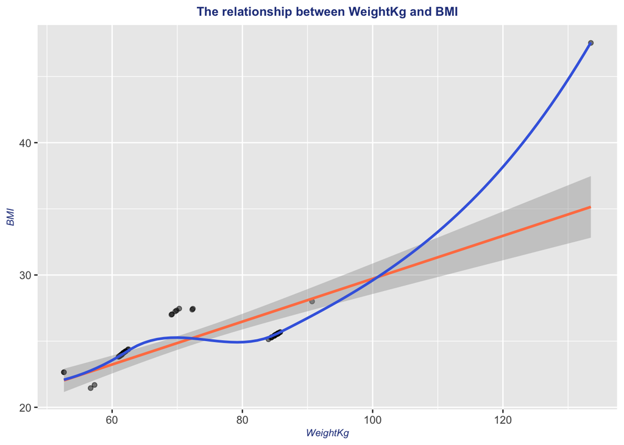

```r
ggplot(Weight, aes(x = WeightKg, y = BMI)) +
  geom_point(alpha = 0.5) +
  geom_smooth(method='lm',
              se = TRUE,
              colour = 'coral') +
  geom_smooth(method='loess',
              se = FALSE,
              colour = 'royalblue') +
  labs(title = "The relationship between WeightKg and BMI",
       x = "WeightKg",
       y = "BMI") +
  theme(plot.title = element_text(color = "royalblue4", face = "bold",
                                  size = 10, hjust =0.5),
        axis.title.x = element_text(color = "royalblue4", size = 8,
                                    face = "italic", hjust =0.5, vjust = 1),
        axis.title.y = element_text(color = "royalblue4", size = 8,
                                    face = "italic", hjust =0.5, vjust = 1))
```

• Insights from the graph:  
From this graph we can see that there is clearly a linear relationship between WeightKg and BMI. The more weight one has, the more BMI one gets.  
• Suggestion according to the insights:  
If customers want to get good BMI, they need to first lose weight. We can calculate how much weight they need to lose to get the targeted BMI. To do that, we will model the linear relationship so that the values of the both variables can be calculated.

##### 5.1.1 Modelling the relationship and evaluating the model

```r
# Modelling
lm0 <- lm(BMI ~ WeightKg, data = Weight)
summary(lm0)
```

```
##
## Call:
## lm(formula = BMI ~ WeightKg, data = Weight)
##
## Residuals:
##     Min      1Q  Median      3Q     Max
## -1.9841 -1.7840  0.4608  0.6021 12.3942
##
## Coefficients:
##             Estimate Std. Error t value Pr(>|t|)
## (Intercept) 13.51151    1.35739   9.954 1.07e-14 ***
## WeightKg     0.16205    0.01851   8.757 1.33e-12 ***
## ---
## Signif. codes:  0 '***' 0.001 '**' 0.01 '*' 0.05 '.' 0.1 ' ' 1
##
## Residual standard error: 2.093 on 65 degrees of freedom
## Multiple R-squared:  0.5412, Adjusted R-squared:  0.5342
## F-statistic: 76.68 on 1 and 65 DF,  p-value: 1.329e-12
```

```r
# Predict
pred.lm0 <- predict(lm0, newdata = Weight)
summary(pred.lm0)
```

```
##    Min. 1st Qu.  Median    Mean 3rd Qu.    Max.
##   22.04   23.46   23.64   25.19   27.29   35.15
```

```r
# Errors that might exist between our Model and predict values
(MAE.lm0 <- mean(abs(Weight$BMI - pred.lm0)))
```

```
## [1] 1.382424
```

There is an error of 1.38 which means our model performance is really good.

To have lose weight, people need to burn calories, Let’s have a look how to better control calories.

#### 5.2 Relationships between TotalDistance and Calories

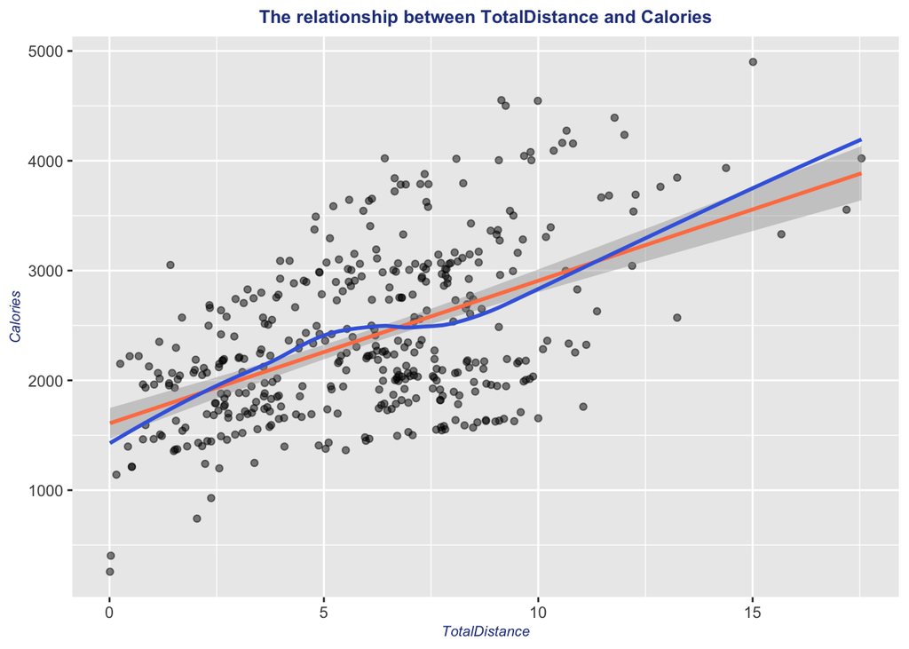

```r
ggplot(ASdata, aes(x = TotalDistance, y = Calories)) +
  geom_point(alpha = 0.5) +
  geom_smooth(method='lm',
              se = TRUE,
              colour = 'coral') +
  geom_smooth(method='loess',
              se = FALSE,
              colour = 'royalblue') +
  labs(title = "The relationship between TotalDistance and Calories",
       x = "TotalDistance",
       y = "Calories") +
  theme(plot.title = element_text(color = "royalblue4", face = "bold",
                                  size = 10, hjust =0.5),
        axis.title.x = element_text(color = "royalblue4", size = 8,
                                    face = "italic", hjust =0.5, vjust = 1),
        axis.title.y = element_text(color = "royalblue4", size = 8,
                                    face = "italic", hjust =0.5, vjust = 1))
```

##### 5.2.1 Modelling the relationship and evaluating the model

```r
# Modelling
lm1 <- lm(TotalDistance ~ Calories, data = ASdata)
summary(lm1)
```

```
##
## Call:
## lm(formula = TotalDistance ~ Calories, data = ASdata)
##
## Residuals:
##     Min      1Q  Median      3Q     Max
## -5.9766 -2.0377 -0.0575  1.7352  8.7412
##
## Coefficients:
##              Estimate Std. Error t value Pr(>|t|)
## (Intercept) 1.0142759  0.4250321   2.386   0.0175 *
## Calories    0.0020919  0.0001696  12.336   <2e-16 ***
## ---
## Signif. codes:  0 '***' 0.001 '**' 0.01 '*' 0.05 '.' 0.1 ' ' 1
##
## Residual standard error: 2.601 on 408 degrees of freedom
## Multiple R-squared:  0.2717, Adjusted R-squared:  0.2699
## F-statistic: 152.2 on 1 and 408 DF,  p-value: < 2.2e-16
```

```r
# Predict
pred.lm1 <- predict(lm1, newdata = ASdata)
summary(pred.lm1)
```

```
##    Min. 1st Qu.  Median    Mean 3rd Qu.    Max.
##   1.552   4.865   5.631   6.012   7.123  11.264
```

```r
# Errors that might exist between our Model and predict values
(MAE.lm1 <- mean(abs(ASdata$TotalDistance - pred.lm1)))
```

```
## [1] 2.139857
```

Notice that people need to walk more if they want to lose calories, let us have a look when do people do sport more intensively.

#### 5.3 The timely intensity of doing activities.

```r
str(HourlyIntensity)
```

```
## 'data.frame':    22099 obs. of  5 variables:
##  $ Id              : num  1.5e+09 1.5e+09 1.5e+09 1.5e+09 1.5e+09 ...
##  $ ActivityHour    : POSIXct, format: "2016-04-12 00:00:00" "2016-04-12 01:00:00" ...
##  $ TotalIntensity  : int  20 8 7 0 0 0 0 0 13 30 ...
##  $ AverageIntensity: num  0.333 0.133 0.117 0 0 ...
##  $ Time            : chr  "00:00:00" "01:00:00" "02:00:00" "03:00:00" ...
```

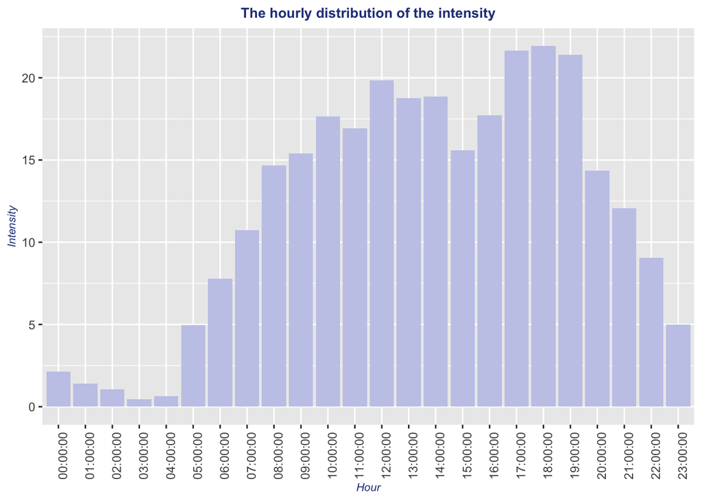

```r
int_new <- HourlyIntensity %>%
  group_by(Time) %>%
  summarise(mean_total_int = mean(TotalIntensity))

ggplot(int_new, aes(x = Time, y = mean_total_int)) +
  geom_histogram(stat = "identity", fill='#C5CAE9') +
  labs(title = "The hourly distribution of the intensity",
       x = "Hour",
       y = "Intensity") +
  theme(plot.title = element_text(color = "royalblue4", face = "bold",
                                  size = 10, hjust =0.5),
        axis.title.x = element_text(color = "royalblue4", size = 8,
                                    face = "italic", hjust =0.5, vjust = 1),
        axis.title.y = element_text(color = "royalblue4", size = 8,
                                    face = "italic", hjust =0.5, vjust = 1),
        axis.text.x = element_text(angle = 90))
```

• Insights from the graph:  
From this graph we can see that there is from 17:00 to 19:00 people is most active. This is probably because that in this time period people just finish their work or school. • Suggestion according to the insights:  
If the customers want to get more exercises, a notification in this time of period is the best.

After examining the factors which are related to the activities, let us have a look at the factor sleep.

#### 5.4 Relationships between sleeptime and other factors.

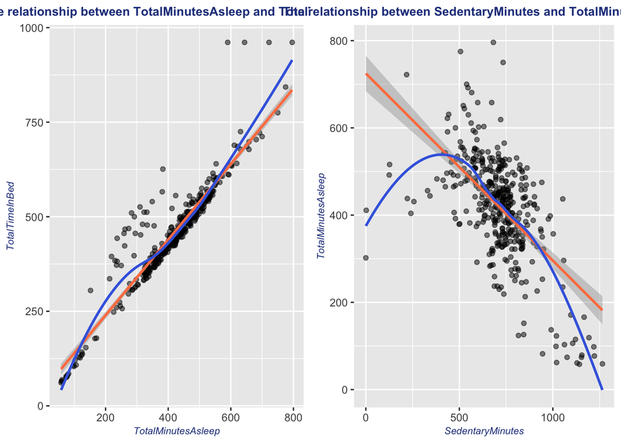

```r
A <-
ggplot(ASdata, aes(x = TotalMinutesAsleep, y = TotalTimeInBed)) +
  geom_point(alpha = 0.5) +
  geom_smooth(method='lm',
              se = TRUE,
              colour = 'coral') +
  geom_smooth(method='loess',
              se = FALSE,
              colour = 'royalblue') +
  labs(title = "The relationship between TotalMinutesAsleep and TotalTimeInBed",
       x = "TotalMinutesAsleep",
       y = "TotalTimeInBed") +
  theme(plot.title = element_text(color = "royalblue4", face = "bold",
                                  size = 10, hjust =0.5),
        axis.title.x = element_text(color = "royalblue4", size = 8,
                                    face = "italic", hjust =0.5, vjust = 1),
        axis.title.y = element_text(color = "royalblue4", size = 8,
                                    face = "italic", hjust =0.5, vjust = 1))

B <-
ggplot(ASdata, aes(x = SedentaryMinutes, y = TotalMinutesAsleep)) +
  geom_point(alpha = 0.5) +
  geom_smooth(method='lm',
              se = TRUE,
              colour = 'coral') +
  geom_smooth(method='loess',
              se = FALSE,
              colour = 'royalblue') +
  labs(title = "The relationship between SedentaryMinutes and TotalMinutesAsleep",
       x = "SedentaryMinutes",
       y = "TotalMinutesAsleep") +
  theme(plot.title = element_text(color = "royalblue4", face = "bold",
                                  size = 10, hjust =0.5),
        axis.title.x = element_text(color = "royalblue4", size = 8,
                                    face = "italic", hjust =0.5, vjust = 1),
        axis.title.y = element_text(color = "royalblue4", size = 8,
                                    face = "italic", hjust =0.5, vjust = 1))

plot_grid(A, B)
```

##### 5.4.1 Modelling the relationship and evaluating the model

```r
lm2 <- lm(TotalMinutesAsleep ~ TotalTimeInBed + SedentaryMinutes, data = ASdata)
summary(lm2)
```

```
##
## Call:
## lm(formula = TotalMinutesAsleep ~ TotalTimeInBed + SedentaryMinutes,
##     data = ASdata)
##
## Residuals:
##      Min       1Q   Median       3Q      Max
## -256.612   -5.984   11.199   21.980   64.432
##
## Coefficients:
##                  Estimate Std. Error t value Pr(>|t|)
## (Intercept)      52.20187   19.56097   2.669  0.00792 **
## TotalTimeInBed    0.84357    0.02148  39.268  < 2e-16 ***
## SedentaryMinutes -0.02779    0.01648  -1.687  0.09243 .
## ---
## Signif. codes:  0 '***' 0.001 '**' 0.01 '*' 0.05 '.' 0.1 ' ' 1
##
## Residual standard error: 43.43 on 407 degrees of freedom
## Multiple R-squared:  0.8666, Adjusted R-squared:  0.866
## F-statistic:  1322 on 2 and 407 DF,  p-value: < 2.2e-16
```

```r
pred.lm2 <- predict(lm2, newdata = ASdata)
summary(pred.lm2)
```

```
##    Min. 1st Qu.  Median    Mean 3rd Qu.    Max.
##   71.88  372.67  422.74  419.17  477.29  856.81
```

```r
(MAE.lm2 <- mean(abs(ASdata$TotalMinutesAsleep - pred.lm2)))
```

```
## [1] 25.89865
```

The MAE value is around 25, which means our model’s performance is not bad.

### 6. Act

#### 6.1 The general trends

Nowdays people do little sports and they sit for too long. As a result of that, they do not burn so much calories everyday and they might be overweighted. The sleep quality is also not perfect. All of those mentioned above could result in pysically and mentally dieseases.

#### 6.2 To apply to Bellabeat customers

The targeted customers of Bellabeat is those who lightly active and a little bit overweighted women. These kind of customer’s purpose of maintaining of using fitness services could be divided into two aspects: lose weight and improve the sleep quality. Accoding to our data, we draw the following conclusion:

• People need to reduce the sedentary time from 16 hours to 10 hours per day.

• They should also walk more, the best would be that the customers could walk for at least 5 miles every day.

#### 6.3 Marketing strategy for now:

• Bellabeat could set some healthy thresholds for the customer. For example, they could set the daily sit hour as 10 hours, daily walk miles as 5 miles, daily time spend on bed is 500 mintues, daily calories to burn is 2500.  
With those threshold, people who wants to generally improve their health can have a better control of their daily activities.

• Bellabeat could use our models to develop a calculate function. Because we have already divided our cutomers into two different categories: the one who wants to lose weight and the one who wants to improve the sleep.  
According to the different type of cutomers, bellabeat could set a function which enable customers to chooes their purposes to use fitness app. Different customers could set the healthy threshold by themselves.  
For example, someone wants to lose weight and they just set the targeted value of the weight. Accoding to the calculate function, customers could check how much they need to walk and sit. For the customers who want to improve their sleep, they could also enter a value of how long they want to sleep more. According to the calculate function, the time to sit and to walk can be also notified to the customer.  
In this way, the fitness app could help the cutomers to acheive their goals more efficiently.

• Through our analysis we found out that during 17-19:00, the intensities of acitivites is the highest, so Bellbeat could set a notification at 17 to enable customers to check, if they have already reach the basic threshold or the threshold they set by themselves every day. If not, they could still do some more to achieve the goals for the day.

• For the customers who achieve their goals, Bellabeat could develop a reward system. For example, customers get a longer Bellabeat membership if they achieve their goal every day for a week. In this way, it is not only easier to motivate people, but also help people to get to know the brand Bellabeat and their products better.

#### 6.4 Marketing strategy for the next step:

Because we have already know the targeted customers are lightly active women who sit more. So it would be wise if Bellbeat collect some information and data about these kind of customers. Bellabeat could analyse their habits and they daily routine, for example, do they watch more TV or computer. What kind of place do they usually go except for work. Do they use Youtube more or Facebook more. In this way, Bellabeat could consider where they should put advertisement to improve their KPI and reduce the ad cost.